# Stock market

Stephen Oates

Saturday, August 16, 2014

Recently I joined up in with some friends to compete in a share trading game run by the Australian Stock Exchange (ASX). They have changed the structure of the game somewhat since the last time we played, removing the ability to buy indexes or commodities listed on the stock market. Instead all you can do is buy 298 of the ASX300 (the largest companies listed). Even short selling is not possible. Instead of going down the usual path of buying shares in things I know, or doing research I think it would be fun to try and use analytics to pick the stocks. I have no illusion this would work (except by chance), but it would be fun to beat my friends who largely work in finance.

For this analysis I will use two separate approaches:

1. Earlier in the year the excellent machine learning blog FastML (well worth subscribing too) had an interesting [post](http://fastml.com/are-stocks-predictable/) on [Forecastable Component Analysis](http://arxiv.org/abs/1205.4591) by Georg M. Georg. Georg has actually created a [CRAN package](http://cran.r-project.org/web/packages/ForeCA/index.html) for the approach which will we try and use.
2. In the excellent book “An introduction to Statistical Learning” (ISWR) by James, Witten, Hastie & Tibshirani they have a part of chapter 4 devoted to building a classification model for dailyLshare movements. Surprisingly the model actually goes quite well at about ~60% accuracy (remembering that 50% would be chance). Lets see if these models do equally well on the ASX data.

So we need Data, lots of data

[figure not shown]

### Start with the index

Often we want to start off simply and increase the complexity from there. So lets begin by getting the data for the ASX300 index and try our techniques on that. Then when the pipeline is working we can move to the actual stocks.

Lets load up our libraries:

```r
library(plyr)
library(dplyr)
library(reshape2)
library(stringr)
library(ggplot2)
library(caret)
```

Sadly it does not seem easy to get lots of data on the ASX300 index (though the individual stocks don’t seem to be a problem).

Lets load the data we can get and have a look.

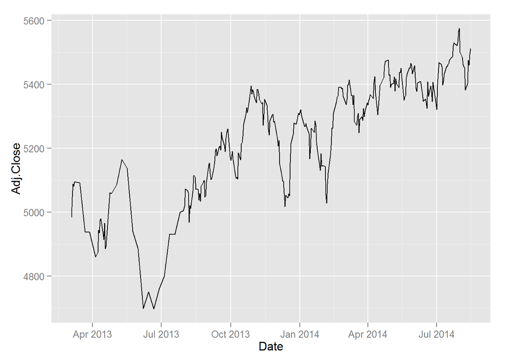

```r
asx300<-read.csv("asx300.csv", header=T)
asx300<-asx300[301:1,]
asx300$Date<-as.Date(asx300$Date, format = "%d/%m/%Y")
ggplot(asx300, aes(x=Date, y=Adj.Close)) + geom_line() + scale_x_date()
```

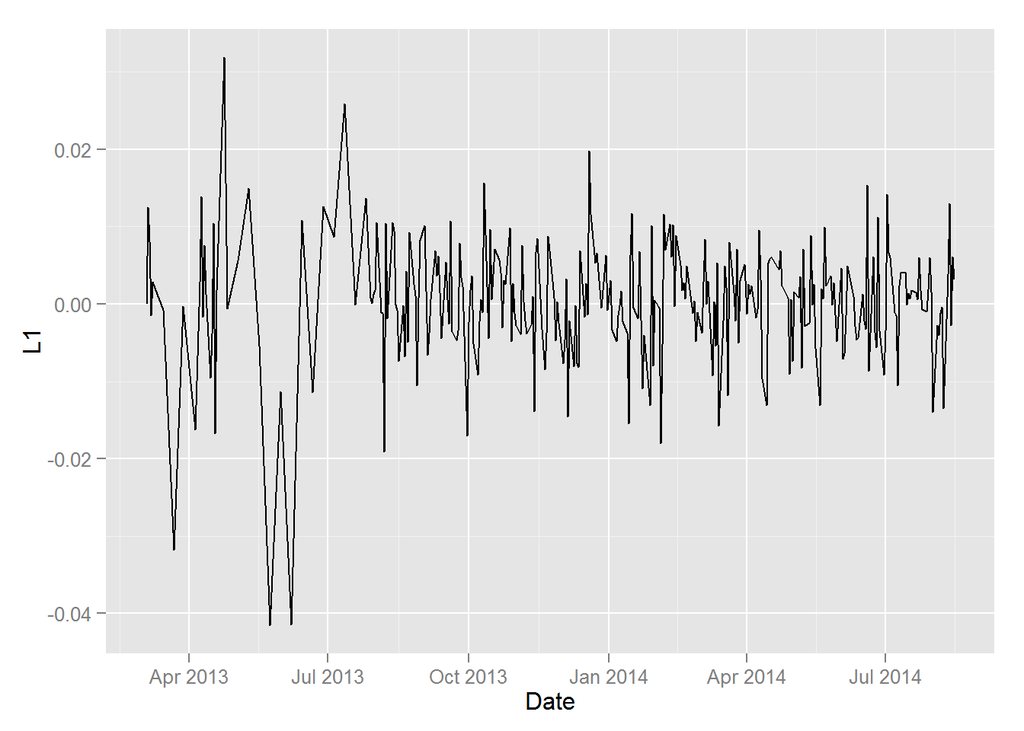

```r
#Now Lets add some Lag columns as we will need the difference for a lot of the latter tasks rather then the actual difference
asx300$Lag1[2:301]<-diff(asx300$Adj.Close, lag=1)
asx300$Lag1[1]<-0
asx300$L1<-asx300$Lag1/(asx300$Lag1+asx300$Adj.Close)
ggplot(asx300, aes(x=Date, y=L1)) + geom_line() + scale_x_date()
```

Lets start super simple and see how we go with just the excellent [forecast package](http://cran.r-project.org/web/packages/forecast/index.html) which is built for time series.

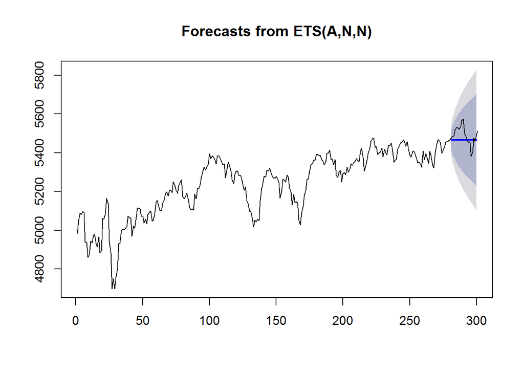

```r
library(forecast)
basic.model<-forecast(asx300$Adj.Close[1:280], h=20)
plot(basic.model)
lines(asx300$Adj.Close)
```

This is not a terrible prediction, but we can see that it is naive (just guessing the last price) and symmetrical. So really this will not help us to become rich.

[figure not shown]

So lets move onto the ForeCA package.

```r
library(ForeCA)
Omega(asx300$L1)
```

```
## [1] 7.324
## attr(,"unit")
## [1] "%"
```

7% out of a 100! Though this does seem to imply that there is possible a tiny something that is predictable as 0% means totally random.

The main function of the ForeCA seems to be about the interaction between different signals (time series) so we will leave that to one side until latter when we have multiple signals.

### Predicting the index

In the example from ISLR the authors use daily closing price, volume, 5 columns for lag of 1-5 days, the amount of movement and the direction.

```r
library(ISLR)
names(Smarket)
```

```
## [1] "Year"      "Lag1"      "Lag2"      "Lag3"      "Lag4"      "Lag5"
## [7] "Volume"    "Today"     "Direction"
```

So lets do the same thing with our data,

```r
#Lag of 2 trading days
asx300$Lag2[3:301]<-diff(asx300$Adj.Close, lag=2)
asx300$Lag2[1:2]<-0
asx300$L2<-asx300$Lag2/(asx300$Lag2+asx300$Adj.Close)

#of 3
asx300$Lag3[4:301]<-diff(asx300$Adj.Close, lag=3)
asx300$Lag3[1:3]<-0
asx300$L3<-asx300$Lag3/(asx300$Lag3+asx300$Adj.Close)

#of 4
asx300$Lag4[5:301]<-diff(asx300$Adj.Close, lag=4)
asx300$Lag4[1:4]<-0
asx300$L4<-asx300$Lag4/(asx300$Lag4+asx300$Adj.Close)

#of 5
asx300$Lag5[6:301]<-diff(asx300$Adj.Close, lag=5)
asx300$Lag5[1:5]<-0
asx300$L5<-asx300$Lag5/(asx300$Lag5+asx300$Adj.Close)
```

```r
asx300$Volume<-stringr::str_replace_all(asx300$Volume, "^0", "NA")
asx300$Volume<-as.numeric(asx300$Volume)
asx300$Volume[!complete.cases(asx300$Volume)]<-median(asx300$Volume, na.rm=T)
```

One important thing to note is that the closing price one day will not (usually) be the opening price the next day. We therefore need to include a column that includes the closing price minus the open. We will also add a new column with the next days movement (Close-Open) as this is what the model will try and predict.

```r
asx300$DailyMove<-asx300$Close-asx300$Open
asx300$Tomorrow<-dplyr::lead(asx300$DailyMove, 1)
#lets drop the last row whilst we are building the model
```

```r
lag_data<-dplyr::select(asx300, DailyMove, Tomorrow, L1, L2, L3, L4, L5)
cor(lag_data, use="complete.obs")
```

```
##           DailyMove Tomorrow       L1       L2       L3       L4       L5
## DailyMove   1.00000 -0.01585  0.85030  0.57418  0.43670  0.33672  0.28274
## Tomorrow   -0.01585  1.00000 -0.01144 -0.02261 -0.06292 -0.08078 -0.07772
## L1          0.85030 -0.01144  1.00000  0.72246  0.62566  0.51126  0.42389
## L2          0.57418 -0.02261  0.72246  1.00000  0.83844  0.73551  0.62144
## L3          0.43670 -0.06292  0.62566  0.83844  1.00000  0.88572  0.78948
## L4          0.33672 -0.08078  0.51126  0.73551  0.88572  1.00000  0.90552
## L5          0.28274 -0.07772  0.42389  0.62144  0.78948  0.90552  1.00000
```

```r
#Lets get rid of the last day and split the data
#data<-na.omit(asx300)
#trainIndex <- caret::createDataPartition(data$Tomorrow, p = .80, list = FALSE, times = 1)
#Train <- data[ trainIndex,]
#Test <- data[-trainIndex, ]
#model building
#rfmodel<-train(Train$Tomorrow~., data=Train, method="rf", trainControl = c(method = "adaptive_cv", number = 10, repeats = 5, classProbs = TRUE, summaryFunction = twoClassSummary, adaptive = list(min = 10, alpha = 0.05, method = "gls", complete = TRUE)))
```

That is about as far as we will go with the ASX300 but lets start to look at individual stocks.

### Individual Stocks

In this share game you can only buy individual stocks, so its time to have a look at them. The first step is download the data. Doing this actually required breaking a Terms of Service for a search engine, so I won’t go into the exact steps I used. (It is not however that difficult).

The data is very similair to the ASX300 data used above, though it goes back further. So lets do the same work on it that we did on the above data.

```r
stock_data<-read.csv("Total1.csv", header=T)
stock_data<-na.omit(stock_data)
stock_data<-as.Date(stock_data$Date)
```

#### References:

1. A [talk](http://techtalks.tv/talks/forecastable-component-analysis/58229/) on Forecast Component Analysis by Georg Georg.